# Ejercicio de modelado de precios y precio por metro cudrado (modelos no lineales).

Jorge Enrique Lamadrid Bazán

10/18/2020

# Introducción

En este ejercicio se hará una regresión múltiple con el ejemplo de Carter-Hill et. al. (2011) de la relación entre el precio de una casa (price) y la superficie en pies cuadrados (sqft). *A priori* se sabe que el precio de las casas del estrato “residencial” tienen un precio mayor poe metro cuadrado. Esto lleva a potenciales no linealidades en el comportamiento de los precios. Veamos los primeros 10 datos de entrada:

Tabla de datos deprecios de casas y metros cuadrados

| price | sqft | bedrooms | baths | age | occupancy | pool | style | fireplace | waterfront | dom |
| --- | --- | --- | --- | --- | --- | --- | --- | --- | --- | --- |
| 66500 | 741 | 1 | 1 | 18 | 1 | 1 | 1 | 1 | 0 | 6 |
| 66000 | 741 | 1 | 1 | 18 | 2 | 1 | 1 | 0 | 0 | 23 |
| 68500 | 790 | 1 | 1 | 18 | 1 | 0 | 1 | 1 | 0 | 8 |
| 102000 | 2783 | 2 | 2 | 18 | 1 | 0 | 1 | 1 | 0 | 50 |
| 54000 | 1165 | 2 | 1 | 35 | 2 | 0 | 1 | 0 | 0 | 190 |
| 143000 | 2331 | 2 | 2 | 25 | 1 | 0 | 1 | 1 | 0 | 86 |
| 98900 | 1228 | 2 | 2 | 25 | 3 | 0 | 1 | 1 | 0 | 123 |
| 98350 | 1228 | 2 | 2 | 25 | 2 | 0 | 1 | 1 | 0 | 137 |
| 98847 | 1228 | 2 | 2 | 25 | 2 | 0 | 1 | 1 | 0 | 168 |
| 98900 | 1228 | 2 | 2 | 25 | 2 | 0 | 1 | 1 | 0 | 135 |

<sup>a</sup> Cifras en USD.

Ahora veamos la comparación entre sqft como regresora y price como regresada (se agrega la recta de regresión y su intervalo de fluctuación al 95% de confianza)

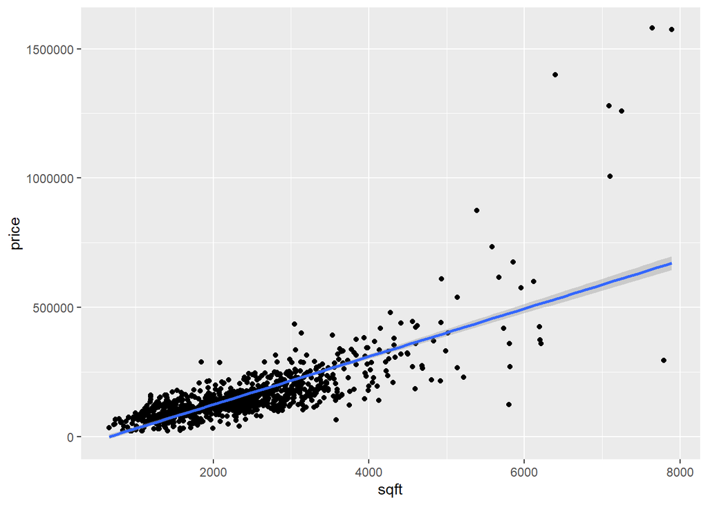

```r
graf1=ggplot(aes(x=sqft,y=price),data=br)+geom_point()+geom_smooth(method="lm")
graf1
```

Como se aprecia, el modelo no es lineal. Por tanto, la idea es hacer una ecuación que estime la media condicionada del precio de las casas considerando las siguientes transformaciones de datos:

1. $price_i=\alpha+\beta\cdot sqrft^2_i+\varepsilon_i$
2. $ln(price_i)=\alpha+\beta\cdot sqrft_i+\varepsilon_i$

# Modelo con los datos de precio y pies cuadrados originales

Se presenta la regresión del modelo original en el que se relaciona tanto los pies cuadrados como el precio:

```r
#Corremos la regresión de la primera ecuación

eqini="price~sqft"
regini=lm(eqini,data=br)

#Se calcula la función de log-verosimilitud (LLF):

LLFvector=c("LlF",round(logLik(regini),4))

#Se calcula la función de Akaike:
AICvector=c("Akaike", round(AIC(regini),4))



# Se calcula el criterio de Schwarz para el modelo:


BICvector=c("Schwarz", round(BIC(regini),4))

# Se calcula el criterio de HANNAN QUIN para el modelo :


HQvector=c("HQ")
     round(-2*logLik(regini)+2*(length(regini$coefficients)*(log(log(nrow(br))))),4)
```

```
## 'log Lik.' 27451.79 (df=3)
```

```r
stargazer(regini, type="text",report="vc*p",add.lines=list(LLFvector,AICvector,BICvector,HQvector))
```

```
##
## ===============================================
##                         Dependent variable:
##                     ---------------------------
##                                price
## -----------------------------------------------
## sqft                         92.747***
##                              p = 0.000
##
## Constant                  -60,861.460***
##                              p = 0.000
##
## -----------------------------------------------
## LlF                         -13722.0075
## Akaike                       27450.015
## Schwarz                     27464.9691
## HQ
## Observations                   1,080
## R2                             0.579
## Adjusted R2                    0.578
## Residual Std. Error   79,821.710 (df = 1078)
## F Statistic         1,480.431*** (df = 1; 1078)
## ===============================================
## Note:               *p<0.1; **p<0.05; ***p<0.01
```

Iniciamos con la primera transformación tentativa(se deja true en echo para que aparezca el código o chunck en la página del resultado, AUNQUE NORMALMENTE SE DEBE PONER FALSE PARA QUE NO APAREZCA)

```r
#Corremos la regresión de la primera ecuación

eq1="log(price)~sqft"
reg1=lm(eq1,data=br)

#Se calcula la función de log-verosimilitud (LLF):

LLFvector=c("LlF",round(logLik(reg1),4))

#Se calcula la función de Akaike:
AICvector=c("Akaike", round(AIC(reg1),4))



# Se calcula el criterio de Schwarz para el modelo:


BICvector=c("Schwarz", round(BIC(reg1),4))

# Se calcula el criterio de HANNAN QUIN para el modelo :


HQvector=c("HQ")
     round(-2*logLik(reg1)+2*(length(reg1$coefficients)*(log(log(nrow(br))))),4)
```

```
## 'log Lik.' 619.3685 (df=3)
```

```r
stargazer(reg1, type="text",report="vc*p",add.lines=list(LLFvector,AICvector,BICvector,HQvector))
```

```
##
## ===============================================
##                         Dependent variable:
##                     ---------------------------
##                             log(price)
## -----------------------------------------------
## sqft                         0.0004***
##                              p = 0.000
##
## Constant                     10.839***
##                              p = 0.000
##
## -----------------------------------------------
## LlF                          -305.7968
## Akaike                       617.5936
## Schwarz                      632.5477
## HQ
## Observations                   1,080
## R2                             0.625
## Adjusted R2                    0.624
## Residual Std. Error      0.321 (df = 1078)
## F Statistic         1,794.780*** (df = 1; 1078)
## ===============================================
## Note:               *p<0.1; **p<0.05; ***p<0.01
```

Para este segundo modelo, veamos como cambia la gráfica con la transformación de los datos ($ln(precio$):

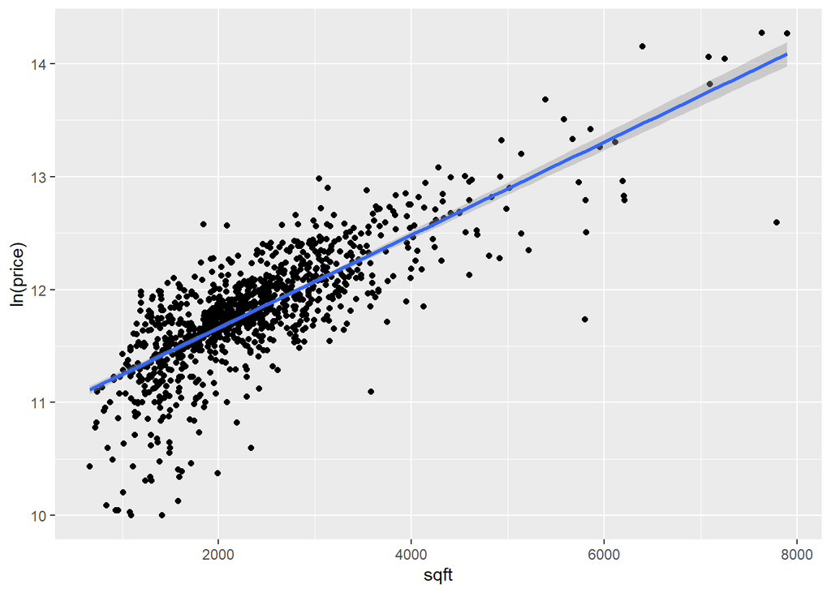

```r
graf2=ggplot(aes(x=sqft,y=log(price)),data=br)+geom_point()+geom_smooth(method="lm")+
  ylab("ln(price)")+xlab("sqft")
graf2
```

Como se puede apreciar, el transformar el precio en su logaritmo natural,hace que el comportamiento de la gráfica de dispersión sea *mas lineal* y por tanto se ajusta mejor el modelo de regresión lineal. Esto en relación a la gráfica con los datos originales.

De manera complementaria, se aprecia que los criterios de información y la función LLF tienen mejores valores de ajuste en este modelo que en el modelo original donde no se transforma el precio. Por tanto se concluye, que este modelo es mejor que el original.

Ahora, si queremos hacer el pronóstico del precio de una casa, dados los pies cuadrados que esta tiene, debemos hacer simplemente la siguiente operación:

$$\widehat{precio}_t=e^{\alpha+\beta\cdot sqft}$$

En pocas palabras se hace un pronóstio con la regresión, sustituyendo sqft y este valor pronosticado será el exponente del número e.Supongamos que una casa tiene una superficie de 7,577 pies cuadrados. Su pronóstico de precio sería el siguiente:

$$\widehat{precio}_t=e^{\10.83+\0.0004\cdot 7,577}$$

```r
pronostico=exp(reg1$coefficients[1]+(reg1$coefficients[2]*1))
pronostico
```

```
## (Intercept)
##    50970.77
```

```r
pronostico=exp(reg1$coefficients[1]+(reg1$coefficients[2]*7577))
pronostico
```

```
## (Intercept)
##     1149434
```

Ahora se realizará la regresión cuadrática de los pies cuadrados:

```r
# Corremos la regresión de la segunda ecuación

eq2="price~I(sqft^2)"
reg2=lm(eq2,data=br)

#Se calcula la función de log-verosimilitud (LLF):

LLFvector=c("LlF",round(logLik(reg2),4))

#Se calcula la función de Akaike:
AICvector=c("Akaike", round(AIC(reg2),4))



# Se calcula el criterio de Schwarz para el modelo:


BICvector=c("Schwarz", round(BIC(reg2),4))

# Se calcula el criterio de HANNAN QUIN para el modelo :


HQvector=c("HQ")
     round(-2*logLik(reg2)+2*(length(reg2$coefficients)*(log(log(nrow(br))))),4)
```

```
## 'log Lik.' 27112.13 (df=3)
```

```r
stargazer(reg2, type="text",report="vc*p",add.lines=list(LLFvector,AICvector,BICvector,HQvector))
```

```
##
## ===============================================
##                         Dependent variable:
##                     ---------------------------
##                                price
## -----------------------------------------------
## I(sqft2)                     0.015***
##                              p = 0.000
##
## Constant                   55,776.570***
##                              p = 0.000
##
## -----------------------------------------------
## LlF                         -13552.1753
## Akaike                      27110.3505
## Schwarz                     27125.3047
## HQ
## Observations                   1,080
## R2                             0.692
## Adjusted R2                    0.692
## Residual Std. Error   68,206.740 (df = 1078)
## F Statistic         2,425.976*** (df = 1; 1078)
## ===============================================
## Note:               *p<0.1; **p<0.05; ***p<0.01
```

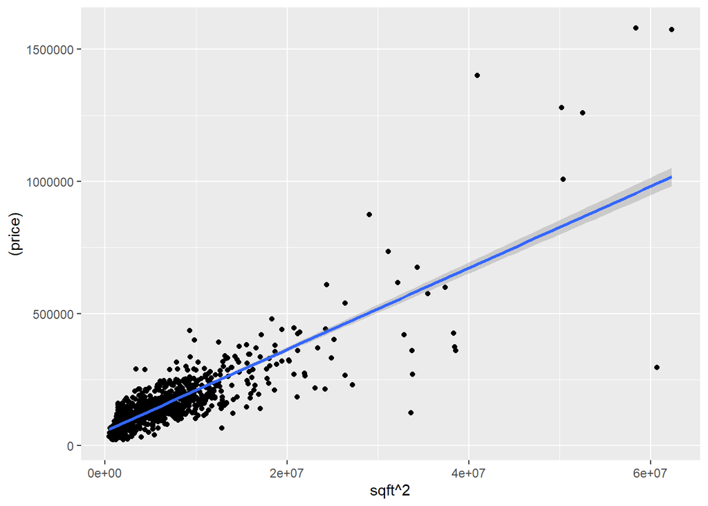

```r
graf3=ggplot(aes(x=sqft^2,y=(price)),data=br)+geom_point()+geom_smooth(method="lm")+
  ylab("(price)")+xlab("sqft^2")
graf3
```